# DATASCI 350 - Data Science Computing

## GitHub in the command line

- [GitHub CLI](https://cli.github.com/) is a command-line tool that brings GitHub to your terminal
- You can install it with `brew install gh`
- GitHub CLI creates repositories, issues, pull requests, and more
- I use it both to create repositories and clone/fork them
  - `gh repo create my-project`
  - `gh repo clone danilofreire/my-project`
- Have a look at the [GitHub CLI manual](https://cli.github.com/manual/) for more information

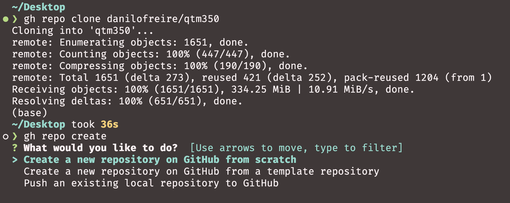

## GitHub Copilot 🤖

- Okay, I have the feeling that you are already tired of me talking about GitHub 😂
- But I’d just like to mention [GitHub Copilot](https://copilot.github.com)
- You may already know it, but it’s been getting many new features
- Now it comes with several good models (Claude, Gemini, etc), and you can use it for free with a [student discount](https://education.github.com/students)
- Like any AI tool, it is not perfect, but it works well and can save you a lot of time

[figure not shown]

## Summary

- `git push` sends your commits to GitHub, `git pull` brings other people’s back
- `.gitignore` keeps data, keys, and generated output out of the repository
- A merge conflict means two people changed the same line. Git marks it, you choose
- Branches let you work without touching `main`, and `merge` brings the work back
- `git switch -c new-branch <hash>` is the safe way to revisit an old commit
- Clone copies a repository to your computer. Fork copies it to your account
- Issues track what needs doing, pull requests propose the change itself
- Pages, Actions, Gists, and the CLI are all built on the same repository

## Next class

- `git diff`: see exactly what changed, line by line, before you commit
- Fixing mistakes: amend a commit message, and undo a commit with `git reset`
- `git cherry-pick`: take one commit from a branch without merging the whole thing
- `git rebase`: replay your commits on top of someone else’s work
- Plus more of the GitHub CLI
- Bring your `my-project` repository. We will keep working on it 🤓

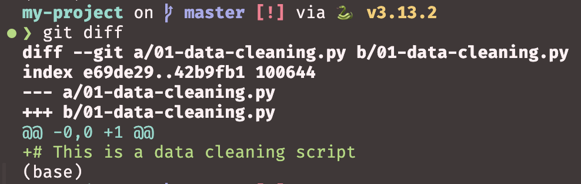

A preview: `git diff` showing one added line

# Phew! That’s all for today! 🎉

# Thank you for your attention and see you soon! 😊🙏